# Bayesian Statistics (47-747) — Homework #1

Daisy Song

2026-09-03

**60 points total.** Provide R code for all relevant problems.

# Problem 1 (10 points): Beta–Binomial with Arcsine Prior

## (a) Posterior, mean, and variance

Given that the probability density function of Beta distribution is given by:
$$f(\theta) =
\frac{1}{B(\alpha,\beta)} \theta^{\alpha-1} (1-\theta)^{\beta-1}, \qquad
0 < \theta < 1,$$
where $B(\alpha,\beta)$ is the Beta function.

The Beta function is defined as:
$$B(\alpha,\beta) =
\frac{\Gamma(\alpha)\Gamma(\beta)}{\Gamma(\alpha+\beta)}$$
where $\Gamma(\cdot)$ is the Gamma function.

the prior can be rewritten as
$$\pi(\theta)
=\frac{\theta^{-1/2}(1-\theta)^{-1/2}}
{B(1/2,1/2)}.$$
Thus,
$$\theta\sim\operatorname{Beta}\left(\frac12,\frac12\right).$$

For the observed data $(S,N)$, the likelihood function is
$$L(\theta\mid S,N)
=\binom NS\theta^S(1-\theta)^{N-S}.$$
When this expression is viewed as a function of $\theta$, the term $\binom NS$ is constant. Therefore,
$$L(\theta\mid S,N)
\propto \theta^S(1-\theta)^{N-S}.$$
By Bayes’ rule,
$$\pi(\theta\mid S,N)
=\frac{L(\theta\mid S,N)\pi(\theta)}{p(S\mid N)}
\propto L(\theta\mid S,N)\pi(\theta),$$
where $p(S\mid N)$ is a normalizing constant that does not depend on $\theta$. Substituting the likelihood and prior gives
$$\begin{aligned}
\pi(\theta\mid S,N)
&\propto
\theta^S(1-\theta)^{N-S}
\theta^{-1/2}(1-\theta)^{-1/2}\\
&=\theta^{S-1/2}(1-\theta)^{N-S-1/2}.
\end{aligned}$$
Comparing this result with the Beta kernel $\theta^{\alpha-1}(1-\theta)^{\beta-1}$ gives
$$\alpha=S+\frac12,
\qquad
\beta=N-S+\frac12.$$
Consequently,
$$\boxed{
\theta\mid S,N\sim
\operatorname{Beta}\left(S+\frac12,N-S+\frac12\right)
}.$$
The normalized posterior density is
$$\pi(\theta\mid S,N)=
\frac{
\theta^{S-1/2}(1-\theta)^{N-S-1/2}
}{
B\left(S+\frac12,N-S+\frac12\right)
}.$$
For $X\sim\operatorname{Beta}(\alpha,\beta)$,
$$E(X)=\frac{\alpha}{\alpha+\beta},
\qquad
\operatorname{Var}(X)=
\frac{\alpha\beta}{(\alpha+\beta)^2(\alpha+\beta+1)}.$$
In this problem, $\alpha+\beta=N+1$. Hence the posterior mean is
$$\boxed{
E(\theta\mid S,N)=\frac{S+1/2}{N+1}
},$$
and the posterior variance is
$$\boxed{
\operatorname{Var}(\theta\mid S,N)=
\frac{(S+1/2)(N-S+1/2)}{(N+1)^2(N+2)}
}.$$

## (b) Plot prior, likelihood, and posterior

Overlay prior, likelihood, and posterior for:

1. $S=1$, $N=1$
2. $S=4$, $N=6$

```r
# define a function for ploting beta-binomial distribution to avoid code duplication
plot_beta_binomial <-
  function(
    S,
    N,
    alpha0 = 0.5,
    beta0 = 0.5,
    main = NULL
    ){
      theta <- ppoints(1000)

      # Prior density
      dens_prior <-
        dbeta(
          x = theta,
          shape1 = alpha0,
          shape2 = beta0
        )

      # Likelihood as a function of theta
      dens_like <-
        dbinom(
          x = S,
          size = N,
          prob = theta
        )

      alpha_n <- S + 0.5
      beta_n  <- N - S + 0.5
      dens_post <-
        dbeta(
          x = theta,
          shape1 = alpha_n,
          shape2 = beta_n
        )

      # Normalize likelihood to the same vertical scale as prior/posterior
      # (shape is preserved; binomial pmf and Beta densities have different units)
      dens_like_plot <- dens_like / max(dens_like) * max(dens_prior, dens_post)

      ylim_max <-
        max(dens_prior, dens_like_plot, dens_post, na.rm = TRUE) * 1.05

      if (is.null(main)) {
        main <- sprintf("S = %d, N = %d", S, N)
      }

    plot(
      x = theta,
      y = dens_prior,
      type = "l",
      lwd = 2,
      col = "red",
        ylim = c(0, ylim_max), xlab = expression(theta), ylab = "Density",
        main = main
    )
    lines(
      x = theta,
      y = dens_like_plot,
      lwd = 2,
      col = "blue"
    )
    lines(
      x = theta,
      y = dens_post,
      lwd = 2,
      col = "darkgreen"
    )
    legend(
      "topright",
      legend = c("Prior", "Likelihood (rescaled)", "Posterior"),
      col = c("red", "blue", "darkgreen"), lwd = 2, bty = "n"
    )
}
```

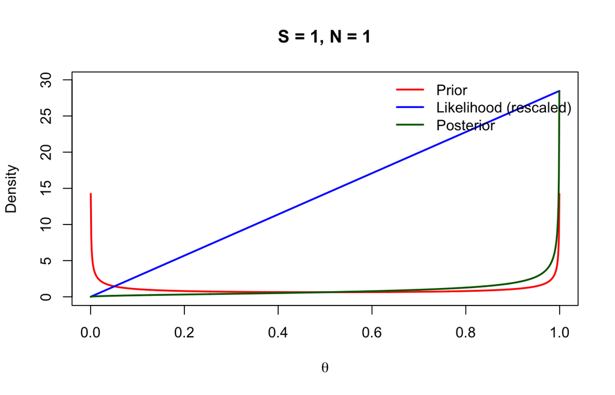

```r
# Case i: S = 1, N = 1
plot_beta_binomial(S = 1, N = 1)
```

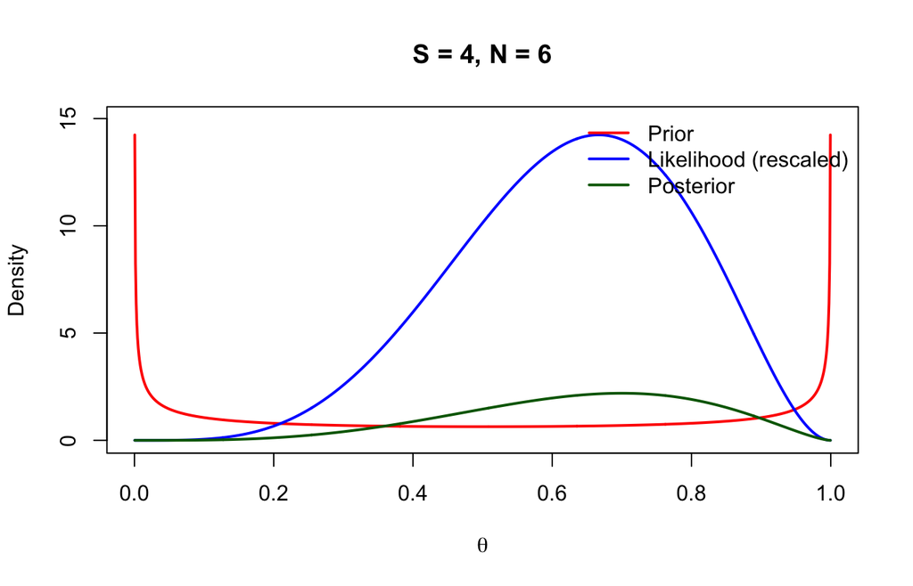

```r
# Case ii: S = 4, N = 6
plot_beta_binomial(S = 4, N = 6)
```

## (c) Sequential update with new data $(S_1, N_1)$

$$\theta\mid S,N
\sim\operatorname{Beta}\left(
S+\frac12,N-S+\frac12
\right).$$
Now suppose an independent second sample produces $S_1$ heads in $N_1$ trials. The likelihood of the second sample is
$$L_1(\theta\mid S_1,N_1)
\propto\theta^{S_1}(1-\theta)^{N_1-S_1}.$$
Using the first posterior as the new prior,
$$\begin{aligned}
\pi(\theta\mid S,N,S_1,N_1)
&\propto
L_1(\theta\mid S_1,N_1)\pi(\theta\mid S,N)\\
&\propto
\theta^{S_1}(1-\theta)^{N_1-S_1}
\theta^{S-1/2}(1-\theta)^{N-S-1/2}\\
&=
\theta^{S+S_1-1/2}
(1-\theta)^{N+N_1-S-S_1-1/2}.
\end{aligned}$$
Therefore,
$$\boxed{
\theta\mid S,N,S_1,N_1
\sim\operatorname{Beta}\left(
S+S_1+\frac12,
N+N_1-S-S_1+\frac12
\right)
}.$$
This is the same posterior that would be obtained by combining both samples into $S+S_1$ total heads from $N+N_1$ total trials.

# Problem 2 (10 points): Combining Normal Forecasts for GDP

Let $\theta$ be next year’s US GDP growth.

## (a) Your prior

Mean $-2\%$ growth, variance $2.25\%$.  
(Work in percentage points: $\mu_0 = -2$, $\sigma_0^2 = 2.25$, so precision $\tau_0 = 1/\sigma_0^2 = 1/2.25 = 4/9$.)

Write the density with mean $\mu_0$ and precision $\tau_0$:

$$p(\theta)
=
\sqrt{\frac{\tau_0}{2\pi}}
\exp\!\left(
-\frac{\tau_0}{2}(\theta-\mu_0)^2
\right),
\qquad
\mu_0=-2,\quad
\tau_0=\frac{1}{2.25}=\frac{4}{9}.$$

Equivalently, $\theta\sim N(\mu_0,\sigma_0^2)=N(-2,2.25)$.

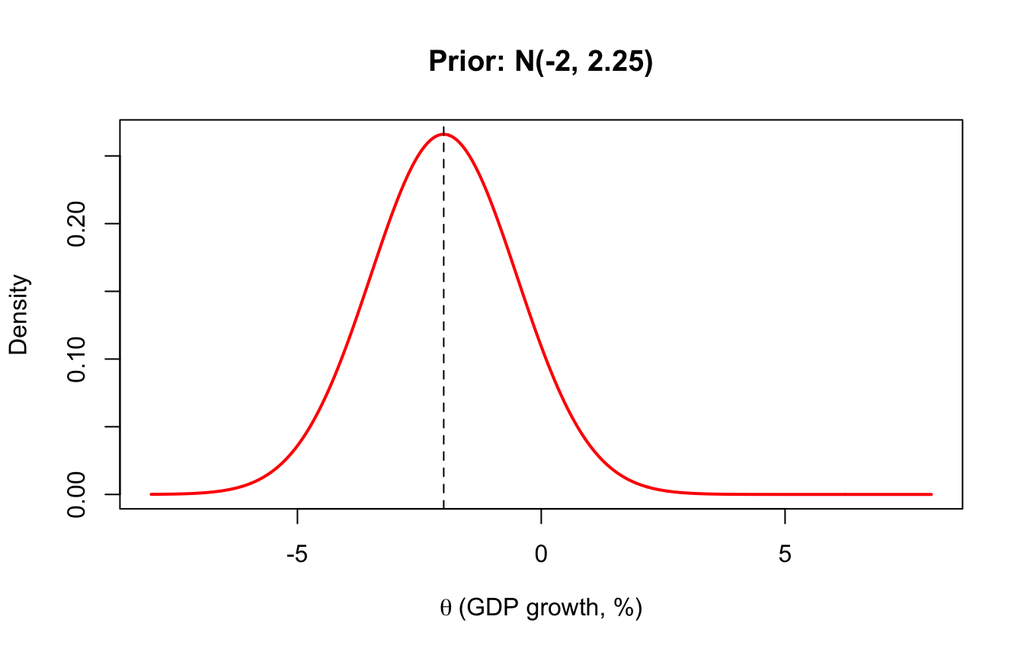

```r
mu0 <- -2
var0 <- 2.25
tau0 <- 1 / var0

theta_grid <-
  seq(
    from = -8,
    to = 8,
    length.out = 1000
  )
dens0 <-
  dnorm(
    x = theta_grid,
    mean = mu0,
    sd = sqrt(var0)
  )

plot(
  x = theta_grid,
  y = dens0,
  type = "l",
  lwd = 2,
  col = "red",
  xlab = expression(theta ~ "(GDP growth, %)"), ylab = "Density",
  main = "Prior: N(-2, 2.25)")
abline(
  v = mu0,
  lty = 2
)
```

```r
# TODO: print mu0, tau0, and the PDF expression in your write-up
c(
  mu0 = mu0,
  tau0 = tau0,
  var0 = var0
)
```

```
##        mu0       tau0       var0
## -2.0000000  0.4444444  2.2500000
```

## (b) Expert’s information

Mean $4\%$ growth, variance $1.5\%$. Independent of yours.  
Write the density with mean $\mu$ and precision $\tau$, and plot it.

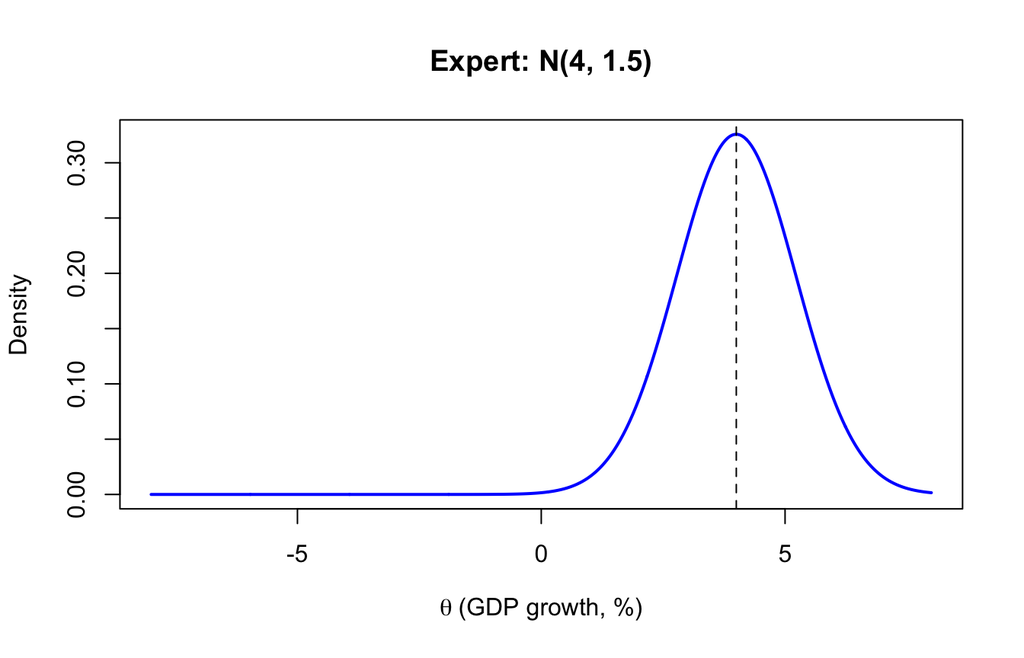

```r
mu  <- 4
var <- 1.5
tau <- 1 / var

dens_exp <-
  dnorm(
    x = theta_grid,
    mean = mu,
    sd = sqrt(var)
  )

plot(
  x = theta_grid,
  y = dens_exp,
  type = "l",
  lwd = 2,
  col = "blue",
     xlab = expression(theta ~ "(GDP growth, %)"), ylab = "Density",
     main = "Expert: N(4, 1.5)")
abline(
  v = mu,
  lty = 2
)
```

```r
c(
  mu = mu,
  tau = tau,
  var = var
)
```

```
##        mu       tau       var
## 4.0000000 0.6666667 1.5000000
```

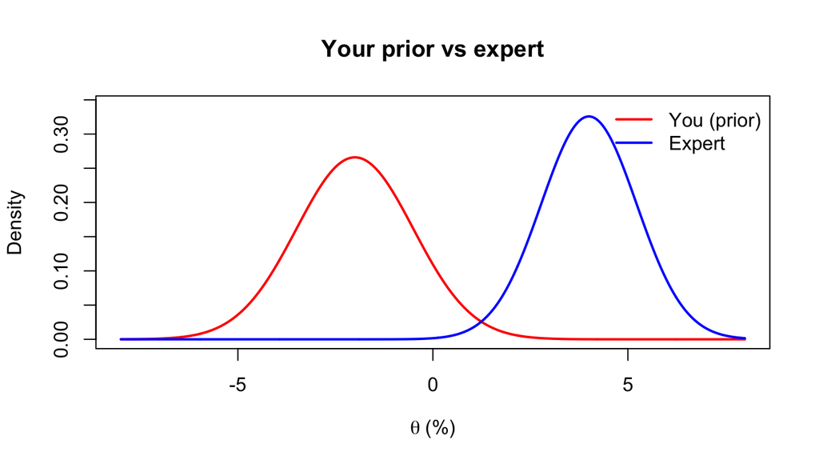

```r
# Optional: overlay both forecasts
plot(theta_grid, dens0, type = "l", lwd = 2, col = "red",
     ylim = c(0, max(dens0, dens_exp) * 1.05),
     xlab = expression(theta ~ "(%)"), ylab = "Density",
     main = "Your prior vs expert")
lines(theta_grid, dens_exp, lwd = 2, col = "blue")
legend("topright", c("You (prior)", "Expert"),
       col = c("red", "blue"), lwd = 2, bty = "n")
```

## (c) Combining the two forecasts

- Treat the expert as independent Normal “data” / information and update your Normal prior.
- Or form the product of the two Normal densities. The combined distribution is again Normal, with precision-weighted mean and summed precisions:
  $$\tau_{\text{post}} = \tau_0 + \tau,
  \qquad
  \mu_{\text{post}} = \frac{\tau_0\mu_0 + \tau\mu}{\tau_{\text{post}}}.$$
  Equivalently, $\theta\mid\text{both}\sim N\!\left(\mu_{\text{post}},\,1/\tau_{\text{post}}\right)$. —

# Problem 3 (10 points): Bayesian Linear Regression

## Data setup

Consider the regression model

$$y_i=\mathbf{x}_i^\top\boldsymbol\beta+\varepsilon_i,
\qquad
\varepsilon_i\sim N(0,\sigma^2),$$

where

$$\boldsymbol\beta=
\begin{pmatrix}
\beta_0\\
\beta_1
\end{pmatrix},
\qquad
\mathbf y=
\begin{pmatrix}
1\\4\\3\\8\\10
\end{pmatrix},
\qquad
X=
\begin{pmatrix}
1&0\\
1&1\\
1&2\\
1&3\\
1&4
\end{pmatrix}.$$

In matrix notation,

$$\mathbf y=X\boldsymbol\beta+\boldsymbol\varepsilon,
\qquad
\boldsymbol\varepsilon\sim N_5(\mathbf0,\sigma^2I_5).$$

Therefore, the likelihood is

$$\mathbf y\mid\boldsymbol\beta,\sigma^2
\sim N_5(X\boldsymbol\beta,\sigma^2I_5).$$

## Preliminary calculations

For the supplied data,

$$X^\top X=
\begin{pmatrix}
5&10\\
10&30
\end{pmatrix},
\qquad
X^\top\mathbf y=
\begin{pmatrix}
26\\74
\end{pmatrix}.$$

The ordinary least-squares estimate is

$$\widehat{\boldsymbol\beta}
=(X^\top X)^{-1}X^\top\mathbf y
=
\begin{pmatrix}
0.8\\2.2
\end{pmatrix}.$$

The residual sum of squares is

$$\operatorname{SSE}
=(\mathbf y-X\widehat{\boldsymbol\beta})^\top
(\mathbf y-X\widehat{\boldsymbol\beta})
=6.4.$$

## General conjugate posterior

Use the conjugate prior

$$\boldsymbol\beta\mid\sigma^2
\sim N_2(\boldsymbol\mu_0,\sigma^2\Lambda_0^{-1})$$

and

$$\sigma^2\sim
\operatorname{Inv}\text{-}\chi^2(\nu_0,\sigma_0^2),$$

where $\Lambda_0$ is the prior precision matrix.

Define

$$\Lambda_n=\Lambda_0+X^\top X,$$

$$\boldsymbol\mu_n=
\Lambda_n^{-1}
\left(\Lambda_0\boldsymbol\mu_0+X^\top\mathbf y\right),$$

$$\nu_n=\nu_0+n,$$

and

$$\sigma_n^2=
\frac{
\nu_0\sigma_0^2+
\mathbf y^\top\mathbf y+
\boldsymbol\mu_0^\top\Lambda_0\boldsymbol\mu_0-
\boldsymbol\mu_n^\top\Lambda_n\boldsymbol\mu_n
}{\nu_n}.$$

The posterior for $\sigma^2$ is

$$\boxed{
\sigma^2\mid\mathbf y
\sim\operatorname{Inv}\text{-}\chi^2(\nu_n,\sigma_n^2)
}.$$

Conditional on $\sigma^2$, the posterior for $\boldsymbol\beta$ is

$$\boxed{
\boldsymbol\beta\mid\sigma^2,\mathbf y
\sim N_2(\boldsymbol\mu_n,\sigma^2\Lambda_n^{-1})
}.$$

After integrating out $\sigma^2$, the marginal posterior is

$$\boxed{
\boldsymbol\beta\mid\mathbf y
\sim t_{\nu_n}
\left(\boldsymbol\mu_n,\sigma_n^2\Lambda_n^{-1}\right)
}.$$

Thus, the posterior mean is

$$E(\boldsymbol\beta\mid\mathbf y)=\boldsymbol\mu_n.$$

The marginal 95% credible interval for $\beta_j$ is

$$\boxed{
\mu_{n,j}\pm
t_{0.975,\nu_n}
\sqrt{\sigma_n^2(\Lambda_n^{-1})_{jj}}
}.$$

The posterior mean of $\sigma^2$ is

$$E(\sigma^2\mid\mathbf y)
=\frac{\nu_n\sigma_n^2}{\nu_n-2},
\qquad \nu_n>2.$$

Its 95% credible interval is

$$\boxed{
\left[
\frac{\nu_n\sigma_n^2}{\chi^2_{0.975,\nu_n}},
\frac{\nu_n\sigma_n^2}{\chi^2_{0.025,\nu_n}}
\right]
}.$$

## Part (a): diffuse prior

Use the diffuse prior

$$\pi(\boldsymbol\beta,\sigma^2)\propto\frac1{\sigma^2}.$$

The conditional posterior for $\boldsymbol\beta$ is

$$\boldsymbol\beta\mid\sigma^2,\mathbf y
\sim N_2\left(
\widehat{\boldsymbol\beta},
\sigma^2(X^\top X)^{-1}
\right).$$

Because $n=5$ and $p=2$, the residual degrees of freedom are

$$\nu=n-p=3.$$

The posterior for $\sigma^2$ is

$$\boxed{
\sigma^2\mid\mathbf y
\sim\operatorname{Inv}\text{-}\chi^2
\left(3,\frac{6.4}{3}\right)
}.$$

The marginal posterior for $\boldsymbol\beta$ is

$$\boxed{
\boldsymbol\beta\mid\mathbf y
\sim t_3\left[
\begin{pmatrix}0.8\\2.2\end{pmatrix},
\frac{6.4}{3}(X^\top X)^{-1}
\right]
}.$$

| Parameter | Posterior mean | 95% credible interval |
| --- | --- | --- |
| $\beta_0$ | 0.800 | $(-2.801,4.401)$ |
| $\beta_1$ | 2.200 | $(0.730,3.670)$ |
| $\sigma^2$ | 6.400 | $(0.685,29.658)$ |

The interval for $\sigma^2$ is wide because there are only three residual degrees of freedom.

## Part (b): informative prior

For the informative prior,

$$\boldsymbol\mu_0=
\begin{pmatrix}1\\2\end{pmatrix},
\qquad
\Lambda_0=I_2,
\qquad
\nu_0=5,
\qquad
\sigma_0^2=0.6.$$

The updated posterior parameters are

$$\Lambda_n=
\begin{pmatrix}
6&10\\10&31
\end{pmatrix},$$

$$\boldsymbol\mu_n=
\begin{pmatrix}
0.89535\\2.16279
\end{pmatrix},
\qquad
\nu_n=10,
\qquad
\sigma_n^2=0.94535.$$

Therefore,

$$\boxed{
\sigma^2\mid\mathbf y
\sim\operatorname{Inv}\text{-}\chi^2(10,0.94535)
}$$

and

$$\boxed{
\boldsymbol\beta\mid\mathbf y
\sim t_{10}
\left(\boldsymbol\mu_n,0.94535\Lambda_n^{-1}\right)
}.$$

| Parameter | Posterior mean | 95% credible interval |
| --- | --- | --- |
| $\beta_0$ | 0.895 | $(-0.405,2.196)$ |
| $\beta_1$ | 2.163 | $(1.591,2.735)$ |
| $\sigma^2$ | 1.182 | $(0.462,2.911)$ |

## Parts (c)–(e): $g$-priors

Use the conventional $g$-prior

$$\boxed{
\boldsymbol\beta\mid\sigma^2
\sim N_2\left[
\boldsymbol\mu_0,
g_0\sigma^2(X^\top X)^{-1}
\right]
}.$$

Equivalently, in precision notation,

$$\Lambda_0=\frac1{g_0}X^\top X.$$

All other prior values remain

$$\boldsymbol\mu_0=
\begin{pmatrix}1\\2\end{pmatrix},
\qquad
\nu_0=5,
\qquad
\sigma_0^2=0.6.$$

For this prior, the posterior mean can be simplified to

$$\boxed{
\boldsymbol\mu_n=
\frac{\boldsymbol\mu_0+g_0\widehat{\boldsymbol\beta}}
{1+g_0}
}.$$

Therefore, $g_0$ determines how the prior mean and the least-squares estimate are weighted.

### Part (c): $g_0=0.1$

$$\boldsymbol\mu_n=
\frac{
\begin{pmatrix}1\\2\end{pmatrix}
+0.1\begin{pmatrix}0.8\\2.2\end{pmatrix}
}{1.1}
=
\begin{pmatrix}
0.9818\\2.0182
\end{pmatrix}.$$

| Parameter | Posterior mean | 95% credible interval |
| --- | --- | --- |
| $\beta_0$ | 0.982 | $(0.463,1.501)$ |
| $\beta_1$ | 2.018 | $(1.806,2.230)$ |
| $\sigma^2$ | 1.243 | $(0.486,3.063)$ |

### Part (d): $g_0=1$

$$\boldsymbol\mu_n=
\frac{
\begin{pmatrix}1\\2\end{pmatrix}
+\begin{pmatrix}0.8\\2.2\end{pmatrix}
}{2}
=
\begin{pmatrix}
0.9\\2.1
\end{pmatrix}.$$

| Parameter | Posterior mean | 95% credible interval |
| --- | --- | --- |
| $\beta_0$ | 0.900 | $(-0.302,2.102)$ |
| $\beta_1$ | 2.100 | $(1.609,2.591)$ |
| $\sigma^2$ | 1.213 | $(0.474,2.987)$ |

### Part (e): $g_0=10$

$$\boldsymbol\mu_n=
\frac{
\begin{pmatrix}1\\2\end{pmatrix}
+10\begin{pmatrix}0.8\\2.2\end{pmatrix}
}{11}
=
\begin{pmatrix}
0.8182\\2.1818
\end{pmatrix}.$$

| Parameter | Posterior mean | 95% credible interval |
| --- | --- | --- |
| $\beta_0$ | 0.818 | $(-0.782,2.418)$ |
| $\beta_1$ | 2.182 | $(1.529,2.835)$ |
| $\sigma^2$ | 1.182 | $(0.462,2.912)$ |

## Part (f): comparison and interpretation

The least-squares estimate of the slope is $2.2$, while its prior mean is $2$. The estimates show the following pattern:

- When $g_0=0.1$, the prior variance is small, so the prior is strong. The posterior slope, $2.018$, is close to the prior mean, and its credible interval is narrow.
- When $g_0=1$, the prior mean and least-squares estimate receive equal weight, giving a posterior slope mean of $2.1$.
- When $g_0=10$, the prior variance is large, so the prior is weak. The posterior slope, $2.182$, is close to the least-squares estimate of $2.2$.
- The diffuse prior contributes almost no prior information and produces the widest credible intervals.

In summary,

$$\boxed{
\text{small }g_0\Longrightarrow\text{stronger prior influence},
\qquad
\text{large }g_0\Longrightarrow\text{stronger data influence}.
}$$

## Density plots for $\beta_1$: prior, likelihood, and posterior

The plots below overlay the **prior**, **likelihood**, and **posterior** densities for $\beta_1$ in parts (a)–(e). Densities are the marginal location–scale Student-$t$ laws implied by the conjugate Normal–Inv-$\chi^2$ model (matching the credible intervals above). For the diffuse prior in (a), the prior is improper, so only the likelihood and posterior are shown (and they coincide for $\boldsymbol\beta$).

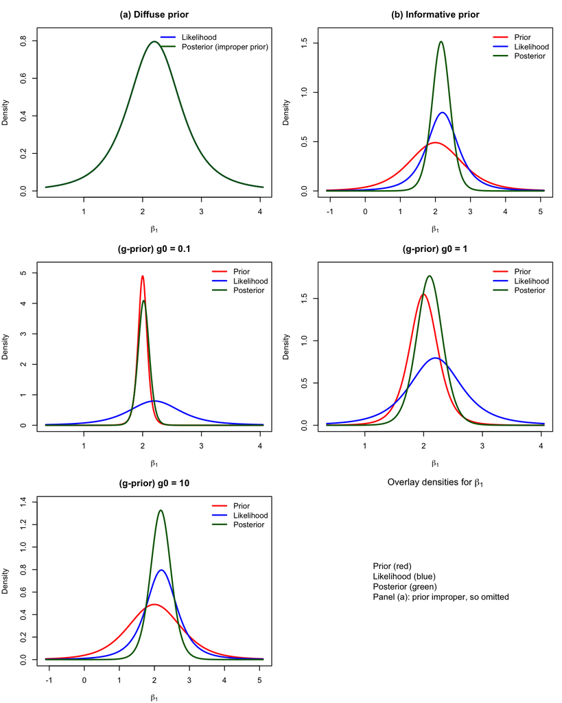

```r
# Data and OLS
y <- c(1, 4, 3, 8, 10)
X <- cbind(1, 0:4)
n <- length(y)
p <- ncol(X)
XtX <- crossprod(X)
Xty <- crossprod(X, y)
beta_hat <- as.numeric(solve(XtX, Xty))
SSE <- sum((y - as.numeric(X %*% beta_hat))^2)
s2_ols <- SSE / (n - p)

# Location-scale Student-t density:
# X = mu + sqrt(scale) * T_nu  =>  f(x) = dt((x-mu)/s, nu) / s
dt_ls <- function(
  x,
  mu,
  scale,
  nu
) {
  s <- sqrt(scale)
  dt((x - mu) / s, df = nu) / s
}

# Conjugate update
update_conj <- function(
  mu0,
  Lambda0,
  nu0,
  sigma0_sq
) {
  Ln <- Lambda0 + XtX
  mun <- as.numeric(solve(Ln, Lambda0 %*% mu0 + Xty))
  nun <- nu0 + n
  sn2 <- as.numeric(
    (
      nu0 * sigma0_sq +
        sum(y^2) +
        drop(t(mu0) %*% Lambda0 %*% mu0) -
        drop(t(mun) %*% Ln %*% mun)
    ) / nun
  )
  list(
    mu0 = mu0,
    L0 = Lambda0,
    mun = mun,
    Ln = Ln,
    nun = nun,
    sn2 = sn2,
    nu0 = nu0,
    sigma0_sq = sigma0_sq
  )
}

like_scale_b1 <- s2_ols * solve(XtX)[2, 2]
like_nu <- n - p

plot_case <- function(
  fit,
  title,
  show_prior = TRUE
) {
  cents <- c(
    fit$mu0[2],
    beta_hat[2],
    fit$mun[2]
  )
  spreads <- c(
    if (show_prior) {
      sqrt(fit$sigma0_sq * solve(fit$L0)[2, 2])
    } else {
      NA
    },
    sqrt(like_scale_b1),
    sqrt(fit$sn2 * solve(fit$Ln)[2, 2])
  )
  lo <- min(cents - 4 * spreads, na.rm = TRUE)
  hi <- max(cents + 4 * spreads, na.rm = TRUE)
  b1_grid <- seq(
    from = lo,
    to = hi,
    length.out = 600
  )

  dens_like <- dt_ls(
    x = b1_grid,
    mu = beta_hat[2],
    scale = like_scale_b1,
    nu = like_nu
  )
  dens_post <- dt_ls(
    x = b1_grid,
    mu = fit$mun[2],
    scale = fit$sn2 * solve(fit$Ln)[2, 2],
    nu = fit$nun
  )

  if (show_prior) {
    dens_prior <- dt_ls(
      x = b1_grid,
      mu = fit$mu0[2],
      scale = fit$sigma0_sq * solve(fit$L0)[2, 2],
      nu = fit$nu0
    )
    ymax <- max(dens_prior, dens_like, dens_post) * 1.05
    plot(
      x = b1_grid,
      y = dens_prior,
      type = "l",
      lwd = 2,
      col = "red",
      ylim = c(0, ymax),
      xlab = expression(beta[1]),
      ylab = "Density",
      main = title
    )
    lines(
      x = b1_grid,
      y = dens_like,
      lwd = 2,
      col = "blue"
    )
    lines(
      x = b1_grid,
      y = dens_post,
      lwd = 2,
      col = "darkgreen"
    )
    legend(
      x = "topright",
      legend = c("Prior", "Likelihood", "Posterior"),
      col = c("red", "blue", "darkgreen"),
      lwd = 2,
      bty = "n"
    )
  } else {
    ymax <- max(dens_like, dens_post) * 1.05
    plot(
      x = b1_grid,
      y = dens_like,
      type = "l",
      lwd = 2,
      col = "blue",
      ylim = c(0, ymax),
      xlab = expression(beta[1]),
      ylab = "Density",
      main = title
    )
    lines(
      x = b1_grid,
      y = dens_post,
      lwd = 2,
      col = "darkgreen"
    )
    legend(
      x = "topright",
      legend = c("Likelihood", "Posterior (improper prior)"),
      col = c("blue", "darkgreen"),
      lwd = 2,
      bty = "n"
    )
  }
}

par(
  mfrow = c(3, 2),
  mar = c(4, 4, 3, 1)
)

# (a) Diffuse prior
fit_a <- list(
  mu0 = beta_hat,
  L0 = diag(2) * 1e-12,
  mun = beta_hat,
  Ln = XtX,
  nun = n - p,
  sn2 = s2_ols,
  nu0 = NA,
  sigma0_sq = NA
)
plot_case(
  fit = fit_a,
  title = "(a) Diffuse prior",
  show_prior = FALSE
)

# (b) Informative prior
fit_b <- update_conj(
  mu0 = c(1, 2),
  Lambda0 = diag(2),
  nu0 = 5,
  sigma0_sq = 0.6
)
plot_case(
  fit = fit_b,
  title = "(b) Informative prior"
)

# (c)--(e) g-priors
for (g0 in c(0.1, 1, 10)) {
  fit_g <- update_conj(
    mu0 = c(1, 2),
    Lambda0 = XtX / g0,
    nu0 = 5,
    sigma0_sq = 0.6
  )
  plot_case(
    fit = fit_g,
    title = sprintf("(g-prior) g0 = %g", g0)
  )
}

# blank 6th panel
plot.new()
title(main = expression("Overlay densities for " * beta[1]))
legend(
  x = "center",
  legend = c(
    "Prior (red)",
    "Likelihood (blue)",
    "Posterior (green)",
    "Panel (a): prior improper, so omitted"
  ),
  bty = "n",
  cex = 1.1
)
```

# Problem 4 (10 points): Prior / Likelihood / Posterior Summaries

For each setting, briefly describe (i) prior, (ii) likelihood, (iii) posterior, including interpretation of parameters.

## (a) Beta–Binomial

*(i) Prior:* $\theta\sim\mathrm{Beta}(\alpha,\beta)$ on $(0,1)$. Here $\theta$ is a success probability (e.g., $P(\text{heads})$). The hyperparameters $\alpha$ and $\beta$ act like prior “pseudo-counts” of successes and failures: larger $\alpha+\beta$ means a stronger prior; $\alpha/(\alpha+\beta)$ is the prior mean.

*(ii) Likelihood:* Given $\theta$, data are $S\sim\mathrm{Binomial}(N,\theta)$ (or $N$ Bernoulli trials), so $L(\theta)\propto\theta^S(1-\theta)^{N-S}$. $S$ is the number of successes in $N$ trials.

*(iii) Posterior:* By conjugacy, $\theta\mid S,N\sim\mathrm{Beta}(\alpha+S,\beta+N-S)$. The posterior mean $(\alpha+S)/(\alpha+\beta+N)$ shrinks the MLE $S/N$ toward the prior mean, with weight depending on prior strength $\alpha+\beta$ versus sample size $N$.

## (b) Poisson data

*(i) Prior:* For a Poisson rate $\lambda>0$, a conjugate prior is $\lambda\sim\mathrm{Gamma}(a,b)$ (shape–rate form). $a$ and $b$ encode prior information about the intensity: prior mean $a/b$, and larger $b$ (for fixed mean) means a more concentrated prior.

*(ii) Likelihood:* Observations $y_1,\ldots,y_n\stackrel{\text{iid}}{\sim}\mathrm{Poisson}(\lambda)$, so $L(\lambda)\propto\lambda^{\sum y_i}e^{-n\lambda}$. $\lambda$ is the expected count per unit time/exposure.

*(iii) Posterior:* $\lambda\mid\mathbf{y}\sim\mathrm{Gamma}\big(a+\sum y_i,\ b+n\big)$. The shape updates by total counts; the rate updates by exposure $n$. The posterior mean $(a+\sum y_i)/(b+n)$ is a precision-weighted blend of the prior mean and the sample mean $\bar y$.

## (c) Normal distribution

*(i) Prior:* For Normal data with unknown mean $\mu$ (and, in the full conjugate case, unknown variance $\sigma^2$), a common prior is $\mu\mid\sigma^2\sim N(\mu_0,\sigma^2/\kappa_0)$ and $\sigma^2\sim\mathrm{Inv\text{-}Gamma}$ (or scaled Inv-$\chi^2$) with hyperparameters $(\nu_0,\sigma_0^2)$. Here $\mu_0$ is the prior guess for the mean, $\kappa_0$ is prior sample size (how strongly we trust $\mu_0$), $\nu_0$ is prior degrees of freedom for $\sigma^2$, and $\sigma_0^2$ is a prior scale for the variance.

*(ii) Likelihood:* $y_1,\ldots,y_n\stackrel{\text{iid}}{\sim} N(\mu,\sigma^2)$. The sample mean $\bar y$ and sample variance summarize the information about $(\mu,\sigma^2)$.

*(iii) Posterior:* The conjugate update keeps the same family: $\mu\mid\sigma^2,\mathbf{y}\sim N(\mu_n,\sigma^2/\kappa_n)$ with $\kappa_n=\kappa_0+n$ and $\mu_n=(\kappa_0\mu_0+n\bar y)/\kappa_n$, and an updated Inv-Gamma / scaled Inv-$\chi^2$ posterior for $\sigma^2$ with degrees of freedom $\nu_n=\nu_0+n$. Thus the posterior mean of $\mu$ shrinks $\bar y$ toward $\mu_0$, with shrinkage controlled by $\kappa_0$ versus $n$.

# Problem 5 (20 points): Readings Discussion

Papers (on Canvas):

1. Rossi & Allenby (1993)
2. Rossi, McCulloch, & Allenby (1996)
3. Montgomery (1997)
4. Montgomery & Rossi (1999)
5. Rossi & Allenby (2003)

**Note:** Empirical Bayes ≠ Hierarchical Bayes (the course treats the latter as “real” Bayes). Cite papers in your answers.

## (a) Random effects vs fixed effects vs Bayesian (e.g. price elasticities)

When estimating household-level price elasticities from scanner panel data, the three approaches differ mainly in how they treat heterogeneity and how they use information across households.

**Fixed effects.** Each household has its own parameters (e.g., brand intercepts and price coefficients), estimated largely from that household’s own purchases. This is flexible, but many households buy infrequently, so household-level MLEs are noisy or even unidentified (Rossi & Allenby, 1993; Rossi, McCulloch, & Allenby, 1996). Fixed effects also do not automatically produce a useful distribution of preferences for predicting new households.

**Random effects (classical hierarchical / mixed logit style).** Household parameters are treated as draws from a population distribution (e.g., $\boldsymbol\beta_h\sim N(\bar{\boldsymbol\beta},\mathbf{V}_\beta)$). Estimation typically targets the population mean and covariance, often by maximizing a marginal likelihood. This pools information across households and shrinks extreme household estimates, but classical implementations often rely on asymptotic approximations and do not fully deliver a joint posterior over all household-level and population-level unknowns. Empirical Bayes variants that plug in a point estimate of the hyper-parameters are related but are not fully Bayesian (Rossi & Allenby, 2003).

**Bayesian (hierarchical Bayes).** The same random-effects structure is embedded in a full probability model: likelihood for choices, prior / hyperprior on the population distribution, and inference for *both* household parameters and hyperparameters (Rossi & Allenby, 1993; Rossi & Allenby, 2003). Posterior means of household elasticities are optimally shrunk toward the population; uncertainty in $\mathbf{V}_\beta$ and $\bar{\boldsymbol\beta}$ is retained rather than plugged in. This is especially valuable for target marketing and micro-pricing, where managers need household- or segment-level elasticities, not only an average slope (Montgomery, 1997; Rossi et al., 1996).

In short: fixed effects = household-specific but data-poor; classical random effects = pooling via a population distribution; hierarchical Bayes = the same pooling idea with full posterior inference and better finite-sample uncertainty quantification.

## (b) Scanner-panel information for household heterogeneity; how to incorporate it

Scanner panels provide rich covariates and purchase histories that help explain why households differ:

1. **Purchase history / revealed preference:** brand chosen, prices paid, promotions seen, purchase timing and quantity (Rossi et al., 1996). These enter the likelihood (e.g., multinomial logit / discrete-choice utility of brand $j$ for household $h$ at occasion $t$).
2. **Demographics and household characteristics:** income, family size, etc., which can shift the mean of household preferences (Rossi & Allenby, 1993; Montgomery, 1997).
3. **Marketing-mix exposure:** feature, display, and price variation that identifies price and promotion sensitivities (Montgomery, 1997).
4. **Theory-based structure:** economic restrictions or prior beliefs about elasticities (e.g., signs, relative magnitudes) that regularize estimates when data are thin (Montgomery & Rossi, 1999).

**How to incorporate them in models:**

- Put demographics in the **upper level** of a hierarchy: e.g., $\boldsymbol\beta_h\sim N(\mathbf{Z}_h\boldsymbol\Delta,\mathbf{V}_\beta)$, so observable traits shift mean preferences (Rossi & Allenby, 1993; Rossi & Allenby, 2003).
- Let purchase histories identify household-level $\boldsymbol\beta_h$ through the **likelihood**.
- Use **informative / theory-based priors** on elasticities or on elements of $\mathbf{V}_\beta$ when panels are short (Montgomery & Rossi, 1999).
- For targeting, combine posterior household parameters with purchase history to score households for promotions (Rossi et al., 1996).

## (c) Why Bayes is useful for household heterogeneity / what data limits it addresses

Scanner panels create a classic **small-$T_h$, large-$H$** problem: many households, but few purchases per household. Household-level MLE then has high variance, unstable elasticities, and sometimes non-existence (perfect classification, collinearity of prices within a household). Hierarchical Bayes addresses this by:

- **Shrinkage / partial pooling:** extreme household elasticities are pulled toward the population, reducing MSE relative to fixed effects (Rossi & Allenby, 1993; Rossi & Allenby, 2003).
- **Borrowing strength:** information from similar households (or demographically similar households) stabilizes estimates for light buyers (Rossi et al., 1996).
- **Proper uncertainty:** posteriors and credible intervals reflect both within-household sampling error and uncertainty about the heterogeneity distribution—important when deciding whether a household is “truly” price sensitive.
- **Decision-ready outputs:** full posterior draws of household parameters support expected-profit targeting and micro-marketing simulations (Montgomery, 1997; Rossi et al., 1996).
- **Regularization via priors:** theory-based priors further curb unreasonable elasticities when identifying variation is weak (Montgomery & Rossi, 1999).

Thus Bayes is particularly useful precisely where the data limitation is **sparse household histories**, not a lack of households overall.

## (d) How marketing researchers use / interpret the prior

In this literature the prior is not merely a computational convenience; it is part of the scientific and managerial model:

1. **Population / hierarchical prior:** $\boldsymbol\beta_h\sim N(\bar{\boldsymbol\beta},\mathbf{V}_\beta)$ (or with demographics in the mean) represents beliefs about how tastes are dispersed in the market. Posterior estimates of $\mathbf{V}_\beta$ are themselves of interest—they measure the extent of heterogeneity relevant for segmentation (Rossi & Allenby, 1993, 2003).
2. **Hyperpriors:** weakly informative priors on $\bar{\boldsymbol\beta}$ and $\mathbf{V}_\beta$ let the panel dominate when $H$ is large, while still regularizing $\mathbf{V}_\beta$ (Rossi & Allenby, 2003).
3. **Theory-based priors:** Montgomery & Rossi (1999) encode economic theory (e.g., plausible signs and magnitudes of price elasticities) so that estimates remain interpretable when likelihood information is limited.
4. **Decision interpretation:** priors / posteriors are often evaluated by **downstream marketing decisions**—targeting lift, profit from customized prices—rather than only by in-sample fit (Rossi et al., 1996; Montgomery, 1997).

Importantly, the course distinction applies: **Empirical Bayes** plugs in a point estimate of the hyper-parameters; **hierarchical Bayes** keeps a prior on those hyper-parameters and integrates them out. The readings emphasize the latter as coherent Bayesian inference (Rossi & Allenby, 2003).

## (e) Hierarchical Bayes and MCMC (why MCMC is needed)

**Hierarchical Bayes (HB).** A multi-level probability model: (i) observation model for choices given household parameters; (ii) household parameters drawn from a population distribution; (iii) priors on the population parameters. Inference targets the joint posterior of all unknowns—$\{\boldsymbol\beta_h\}_{h=1}^H$, $\bar{\boldsymbol\beta}$, $\mathbf{V}_\beta$, etc. (Rossi & Allenby, 1993, 2003).

**MCMC (e.g., Gibbs sampling / Metropolis–Hastings).** A simulation method that generates draws from the joint posterior when the posterior has no closed form. Typical HB logit models alternate between:

- drawing each $\boldsymbol\beta_h\mid\text{data}_h,\bar{\boldsymbol\beta},\mathbf{V}_\beta$,
- drawing $\bar{\boldsymbol\beta},\mathbf{V}_\beta\mid\{\boldsymbol\beta_h\}$,

and so on (Rossi & Allenby, 2003).

**Why MCMC is needed here.** With discrete-choice likelihoods and hundreds/thousands of household parameter vectors, the joint posterior is high-dimensional and analytically intractable; the marginal likelihood for classical random-effects estimation is also a difficult integral. MCMC provides practical access to household-level posteriors and to functions of parameters (elasticities, optimal prices, targeting scores) by averaging over draws (Rossi et al., 1996; Montgomery, 1997; Rossi & Allenby, 2003). Without MCMC (or another computational Bayes method), fully Bayesian hierarchical inference for these marketing models would generally be infeasible.